# assignment_5_classification_BERT_compare_truncate_segment

```python
!pip install datasets
```

[output not shown]

```python
!pip install accelerate
```

```python
# !pip install --upgrade numpy pandas
```

```python
!pip install numpy==1.23.5
```

```python
!pip install --force-reinstall pyarrow
```

[output not shown]

```python
!pip install tf-keras
```

[output not shown]

```python
import torch
import pandas as pd
import numpy as np
from datasets import load_dataset
from transformers import (
    AutoModel,
    AutoTokenizer,
    AutoModelForSequenceClassification,
    Trainer,
    TrainingArguments,
    DataCollatorWithPadding
)

from sklearn.linear_model import LogisticRegression
from sklearn.dummy import DummyClassifier
from sklearn.metrics import (
    ConfusionMatrixDisplay,
    confusion_matrix,
    accuracy_score,
    f1_score
)
import matplotlib.pyplot as plt
import accelerate
print(accelerate.__version__)
```

```
1.1.0
```

```python
if torch.cuda.is_available():
    device = "cuda"
else:
    device = "cpu"

print(f"Setting device to '{device}'")
```

```
Setting device to 'cuda'
```

```python
# Load the dataset

dataset = load_dataset('ccdv/patent-classification')
```

```python
dataset
```

```
DatasetDict({
    train: Dataset({
        features: ['text', 'label'],
        num_rows: 25000
    })
    validation: Dataset({
        features: ['text', 'label'],
        num_rows: 5000
    })
    test: Dataset({
        features: ['text', 'label'],
        num_rows: 5000
    })
})
```

```python
print(
    f"{dataset.shape=}",
    f"{dataset.num_columns=}",
    f"{dataset.num_rows=}",
    f"{dataset.column_names=}",
    sep="\n\n"
)
```

```
dataset.shape={'train': (25000, 2), 'validation': (5000, 2), 'test': (5000, 2)}

dataset.num_columns={'train': 2, 'validation': 2, 'test': 2}

dataset.num_rows={'train': 25000, 'validation': 5000, 'test': 5000}

dataset.column_names={'train': ['text', 'label'], 'validation': ['text', 'label'], 'test': ['text', 'label']}
```

```python
# accessing the training split
# note the difference in object types

train = dataset["train"]
train
```

```
Dataset({
    features: ['text', 'label'],
    num_rows: 25000
})
```

```python
# example for accessing a single example via index

train[0]
```

```
{'text': 'turning now to the drawings , there is shown in fig1 an integrated circuit continuity testing system in which a specimen or circuit configuration 16 is mounted on a fixture 18 operable to vibrate the specimen under controlled conditions , e . g . sinusoidally , randomly , or a combination …
 'label': 6}
```

```python
# example for checking the labels in the dataset

train.features
```

```
{'text': Value(dtype='string', id=None),
 'label': ClassLabel(names=['Human Necessities', 'Performing Operations; Transporting', 'Chemistry; Metallurgy', 'Textiles; Paper', 'Fixed Constructions', 'Mechanical Engineering; Lightning; Heating; Weapons; Blasting', 'Physics', 'Electricity', 'General tagging of new or cross-sectional technology'…
```

```python
# example for switching to different output format

dataset.set_format(type="pandas")

df = dataset["train"][:]
df.head()
```

|  | text | label |
| --- | --- | --- |
| 0 | turning now to the drawings , there is shown i... | 6 |
| 1 | deployment mechanisms that are configured for ... | 0 |
| 2 | now , first and second embodiments of the pres... | 7 |
| 3 | as used herein , “ administration ” of a compo... | 0 |
| 4 | in accordance with the figures , the mixing de... | 8 |

The int2str method in dataset["train"].features["label"].int2str(row) is specific to the Hugging Face Dataset object. It converts integer label IDs to their corresponding string names based on the dataset's label mapping.

```python
# example to view the labels in comprehensive text

def label_int2str(row):
    """Return the corresponding label name from the integer."""
    return dataset["train"].features["label"].int2str(row)

df["label_name"] = df["label"].apply(label_int2str)
df.head()
```

|  | text | label | label_name |
| --- | --- | --- | --- |
| 0 | turning now to the drawings , there is shown i... | 6 | Physics |
| 1 | deployment mechanisms that are configured for ... | 0 | Human Necessities |
| 2 | now , first and second embodiments of the pres... | 7 | Electricity |
| 3 | as used herein , “ administration ” of a compo... | 0 | Human Necessities |
| 4 | in accordance with the figures , the mixing de... | 8 | General tagging of new or cross-sectional tech... |

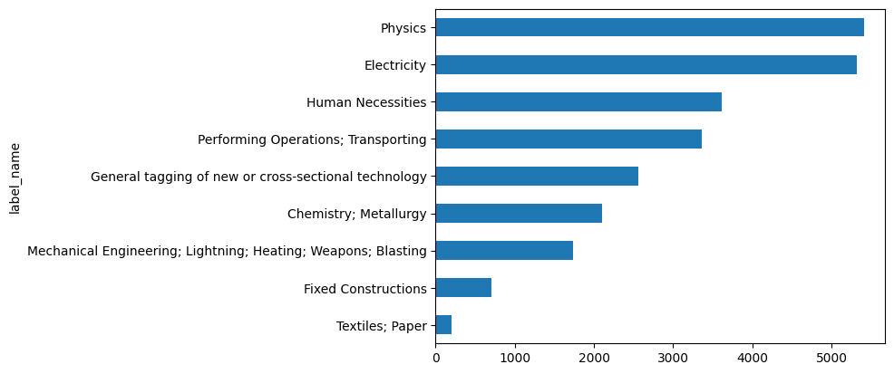

```python
# example to view the class distribution in the dataset

df["label_name"].value_counts(ascending=True).plot.barh()
```

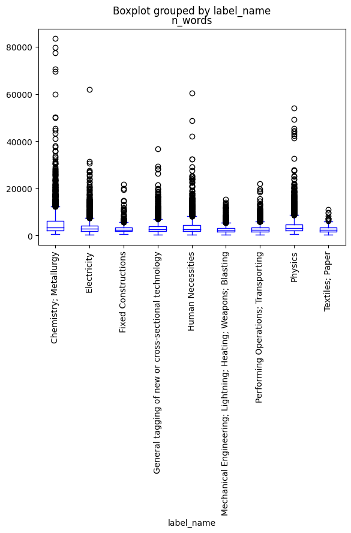

```python
# Visualize the length of sentences in each group

df["n_words"] = df["text"].str.split().str.len()
df.boxplot("n_words", by="label_name", grid=False, color="blue")

# Rotate x-axis labels by 90 degrees

plt.xticks(rotation=90)
plt.show()
```

```python
# Top 4 labels

# Get the top 4 most frequent label names
top_labels = df["label_name"].value_counts().head(4).index.tolist()
top_labels
```

```
['Physics',
 'Electricity',
 'Human Necessities',
 'Performing Operations; Transporting']
```

```python
# Get the label indices for the top 4 labels

label_to_id = {label: idx for idx, label in enumerate(dataset['train'].features['label'].names)}
top_label_ids = [label_to_id[label] for label in top_labels]
top_label_ids
```

```
[6, 7, 0, 1]
```

```python
# Filter the dataset

def filter_top_labels(example):
    return example['label'] in top_label_ids

filtered_dataset = dataset.filter(filter_top_labels)

# Verify the filtered dataset
print(filtered_dataset)
```

```
DatasetDict({
    train: Dataset({
        features: ['text', 'label'],
        num_rows: 17700
    })
    validation: Dataset({
        features: ['text', 'label'],
        num_rows: 3549
    })
    test: Dataset({
        features: ['text', 'label'],
        num_rows: 3545
    })
})
```

```python
# For the filtered_dataset

# Convert label indices to label names to check
def label_int2str(row):
    """Return the corresponding label name from the integer."""
    return filtered_dataset['train'].features['label'].int2str(row)

df = filtered_dataset['train'].to_pandas()
df['label_name'] = df['label'].apply(label_int2str)

# Check the unique label names in the filtered dataset
print(df['label_name'].unique())
```

```
['Physics' 'Human Necessities' 'Electricity'
 'Performing Operations; Transporting']
```

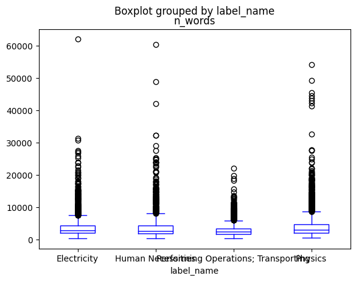

```python
# visual the length of sentences in each group under filtered_dataset

df["n_words"] = df["text"].str.split().str.len()
df.boxplot("n_words", by="label_name", grid=False, color="blue")
```

```python
top_labels
```

```
['Physics',
 'Electricity',
 'Human Necessities',
 'Performing Operations; Transporting']
```

```python
top_label_ids
```

```
[6, 7, 0, 1]
```

```python
filtered_dataset.reset_format()
try:
    del df
except:
    pass
```

# Method 1: Fine-tune a transformer model with text truncation

```python
# Ressign the labels in filtered_dataset to align with a new ClassLabel feature containing only the top labels, with the label indices updated accordingly.
# I want to work with a reduced set of labels and ensure that they have a consistent and clear indexing scheme.

from datasets import ClassLabel

# Create a new ClassLabel feature with only the top labels
new_labels = ClassLabel(names=top_labels)
# A dictionary new_label_map is created to map the original label IDs (old_ids) from filtered_dataset to new label IDs (new_ids) within the range of the top labels.
# This dictionary comprehension iterates over top_label_ids and assigns each old label ID to a new label ID that corresponds to its index in top_labels.
new_label_map = {old_id: new_labels.str2int(new_labels.int2str(new_id)) for new_id, old_id in enumerate(top_label_ids)}

# The remap_label function updates each example in filtered_dataset by replacing its label with the new mapped label ID from new_label_map.
def remap_label(example):
    example['label'] = new_label_map[example['label']]
    return example

# Transform filtered_dataset into remapped_dataset, where labels are now indexed according to the new ClassLabel mapping.
remapped_dataset = filtered_dataset.map(remap_label)

# Cast the label column in remapped_dataset to the newly created new_labels feature,
# ensuring the dataset's label column has the correct, updated mapping with only the top labels.
remapped_dataset = remapped_dataset.cast_column('label', new_labels)
```

```python
remapped_dataset
```

```
DatasetDict({
    train: Dataset({
        features: ['text', 'label'],
        num_rows: 17700
    })
    validation: Dataset({
        features: ['text', 'label'],
        num_rows: 3549
    })
    test: Dataset({
        features: ['text', 'label'],
        num_rows: 3545
    })
})
```

```python
n_classes = len(remapped_dataset["train"].features["label"].names)
n_classes
```

```
4
```

```python
for index, label_name in enumerate(remapped_dataset["train"].features["label"].names):
    print(f"Label index: {index}, Label name: {label_name}")
```

```
Label index: 0, Label name: Physics
Label index: 1, Label name: Electricity
Label index: 2, Label name: Human Necessities
Label index: 3, Label name: Performing Operations; Transporting
```

```python
# load a base model
model_ckpt = "distilbert-base-uncased"
model = AutoModelForSequenceClassification.from_pretrained(model_ckpt, num_labels=n_classes).to(device)
```

```
Some weights of DistilBertForSequenceClassification were not initialized from the model checkpoint at distilbert-base-uncased and are newly initialized: ['classifier.bias', 'classifier.weight', 'pre_classifier.bias', 'pre_classifier.weight']
You should probably TRAIN this model on a down-stream task to be able to use it for predictions and inference.
```

```python
tokenizer = AutoTokenizer.from_pretrained(model_ckpt)
```

```python
# tokenize
max_length = 128
def tokenize(batch):
    return tokenizer(batch["text"], truncation=True, max_length=max_length, padding='max_length')
```

```python
batch_size = 100 # The tokenize function will receive a batch of 100 examples each time it’s called.
dataset_tokens = remapped_dataset.map(tokenize, batched=True, batch_size=batch_size)
```

```python
try:
    np.array(dataset_tokens["train"]["input_ids"]).shape
except Exception as e:
    print(f"Caught an exception: {e}")
```

```python
np.array(dataset_tokens["train"]["input_ids"]).shape
```

```
(17700, 128)
```

```python
data_collator = DataCollatorWithPadding(tokenizer=tokenizer)
```

```python
def compute_metrics(pred):
    """
    Calcualtes accuracy and f1 score given predictions.

    Args:
        pred (EvalPrediction):
    """
    labels = pred.label_ids
    preds = pred.predictions.argmax(-1)
    f1 = f1_score(labels, preds, average="weighted")
    acc = accuracy_score(labels, preds)
    return {"accuracy": acc, "f1": f1}
```

```python
len(dataset_tokens["train"])
```

```
17700
```

Total steps (batches) per epoch = 17700/75=236 logs once per epoch

```python
# Training arguments
batch_size = 75
logging_steps = len(dataset_tokens["train"]) // batch_size

training_args = TrainingArguments(
    output_dir=f"{model_ckpt}-finetuned-dataset",
    num_train_epochs=2,
    learning_rate=2e-5,
    per_device_train_batch_size=batch_size,
    per_device_eval_batch_size=batch_size,
    weight_decay=0.01,
    evaluation_strategy="epoch",
    disable_tqdm=False,
    logging_steps=logging_steps,
    push_to_hub=False,
    log_level="error"
)
```

```python
trainer = Trainer(
    model=model,
    args=training_args,
    compute_metrics=compute_metrics,
    train_dataset=dataset_tokens["train"],
    eval_dataset=dataset_tokens["validation"],
    tokenizer=tokenizer,
    data_collator=data_collator
)
```

```python
trainer.train()
```

[472/472 10:10, Epoch 2/2]

| Epoch | Training Loss | Validation Loss | Accuracy | F1 |
| --- | --- | --- | --- | --- |
| 1 | 0.888700 | 0.744718 | 0.714567 | 0.715434 |
| 2 | 0.671000 | 0.714099 | 0.722175 | 0.722670 |

```
I0000 00:00:1730911881.423518    8325 asm_compiler.cc:379] ptxas warning : Registers are spilled to local memory in function 'gemm_fusion_dot_5995', 764 bytes spill stores, 760 bytes spill loads
```

```
TrainOutput(global_step=472, training_loss=0.7798786163330078, metrics={'train_runtime': 611.7367, 'train_samples_per_second': 57.868, 'train_steps_per_second': 0.772, 'total_flos': 1172378292019200.0, 'train_loss': 0.7798786163330078, 'epoch': 2.0})
```

```python
pred_output = trainer.predict(dataset_tokens["validation"])
pred_output
```

```
PredictionOutput(predictions=array([[ 1.7893314 ,  0.5177877 , -1.9332374 , -0.7650838 ],
       [ 2.2310073 ,  0.842461  , -1.6544565 , -1.9814094 ],
       [ 0.6638375 , -0.67629063, -0.66016704,  0.8240031 ],
       ...,
       [ 2.0305295 ,  0.3840783 , -1.1799802 , -1.464259  ],
       [-0.87875545, -1.6299324 ,  2.0502825 ,  1.1812395 ],
       [ 1.6987516 , -0.41298407, -1.4494139 ,  0.03600585]],
      dtype=float32), label_ids=array([0, 0, 3, ..., 0, 2, 3]), metrics={'test_loss': 0.7140994668006897, 'test_accuracy': 0.722175260636799, 'test_f1': 0.7226703464236943, 'test_runtime': 12.444, 'test_samples_per_second': 289.295, 'test_steps_per_second': 3.857})
```

```python
pred_output.metrics
```

```
{'test_loss': 0.7140994668006897,
 'test_accuracy': 0.722175260636799,
 'test_f1': 0.7226703464236943,
 'test_runtime': 12.444,
 'test_samples_per_second': 289.295,
 'test_steps_per_second': 3.857}
```

```python
y_pred = pred_output.predictions.argmax(axis=1)
y_pred
```

```
array([0, 0, 3, ..., 0, 2, 0])
```

```python
y_test = np.array(dataset_tokens["validation"]["label"])
```

```python
def plot_confusion_matrix(y_preds, y_true, labels):
    cm = confusion_matrix(y_true, y_preds, normalize="true")
    fig, ax = plt.subplots(figsize=(6, 6))
    disp = ConfusionMatrixDisplay(confusion_matrix=cm, display_labels=labels)
    disp.plot(cmap="Blues", values_format=".2f", ax=ax, colorbar=False)
    plt.xticks(rotation=45)  # Rotate x-axis labels by 45 degrees
    plt.title("Normalized confusion matrix")
    plt.show()
```

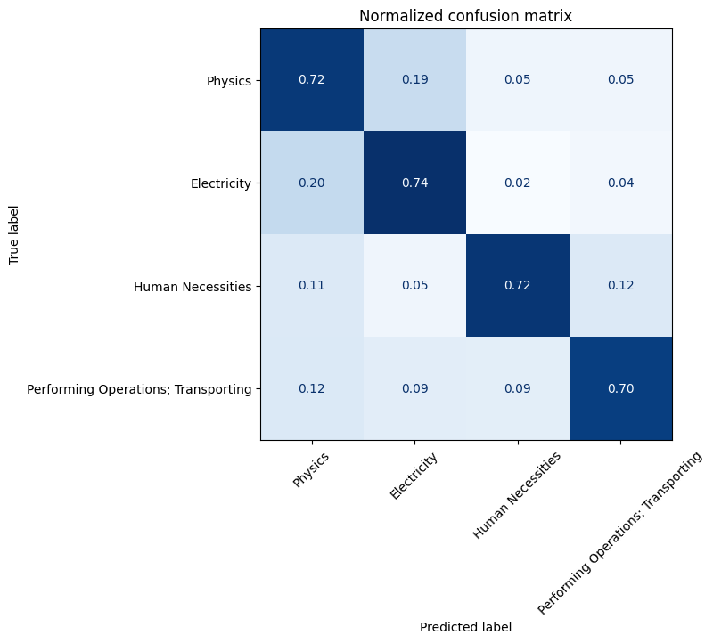

```python
plot_confusion_matrix(y_pred, y_test, remapped_dataset["train"].features["label"].names)
```

### Decent result with Method 1: Fine-tune a transformer model with text truncation.

# Method 2: Fine-tune a transformer model by segmenting the text such that it fits within the context window of the model.

### The segmentation approach processes long text sequences by breaking them into smaller chunks that fit within the model's context window

```python
# text.split() splits the text into individual words.
# The for loop iterates over words in steps of max_length, creating chunks of words that each have a length up to max_length.
# Each chunk is joined back into a string of words and yielded as a separate chunk, so the function can handle long text by generating smaller text segments.

def chunk_text(text, max_length):
    words = text.split()
    for i in range(0, len(words), max_length):
        yield ' '.join(words[i:i + max_length])

# This function tokenizes each chunk produced by chunk_text and prepares them for input into the model.

def tokenize_and_segment(example, max_length=128):
    chunks = list(chunk_text(example['text'], max_length))
    tokenized_chunks = [tokenizer(chunk, truncation=True, max_length=max_length, padding='max_length') for chunk in chunks]

    input_ids = [tokenized_chunk['input_ids'] for tokenized_chunk in tokenized_chunks]
    attention_mask = [tokenized_chunk['attention_mask'] for tokenized_chunk in tokenized_chunks]
    # Replicates the label for each chunk of the text, ensuring each segment has the same label.
    labels = [example['label']] * len(chunks)

    return {
        'input_ids': input_ids,
        'attention_mask': attention_mask,
        'labels': labels
    }
```

```python
remapped_dataset
```

```
DatasetDict({
    train: Dataset({
        features: ['text', 'label'],
        num_rows: 17700
    })
    validation: Dataset({
        features: ['text', 'label'],
        num_rows: 3549
    })
    test: Dataset({
        features: ['text', 'label'],
        num_rows: 3545
    })
})
```

```python
from datasets import Dataset, DatasetDict
import itertools

max_length = 128  # Set to model's max length or a smaller value

# Preprocess a dataset by segmenting and tokenizing long text sequences, then flattens these segmented chunks into a new dataset ready for training or evaluation.
def preprocess_dataset(dataset):
    # Apply the tokenization and segmentation function to each example in the dataset
    # tokenized_examples: The map function applies tokenize_and_segment to each example in dataset.
    # Setting batched=False ensures tokenize_and_segment is applied to each example independently.
    # The result is a new dataset (tokenized_examples) where each text example has been broken into tokenized chunks, each with fields input_ids, attention_mask, and labels.
    tokenized_examples = dataset.map(lambda x: tokenize_and_segment(x, max_length), batched=False)

    # Flatten the tokenized chunks into a single dataset
    # Flattening with itertools.chain.from_iterable: This operation takes the lists of tokenized chunks (nested lists) and flattens them into a single list for each field.
    # For example, if the dataset contains three examples, each split into multiple chunks, input_ids will become one list of all chunked input_ids from the entire dataset.
    input_ids = list(itertools.chain.from_iterable(tokenized_examples['input_ids']))
    attention_mask = list(itertools.chain.from_iterable(tokenized_examples['attention_mask']))
    labels = list(itertools.chain.from_iterable(tokenized_examples['labels']))

    # Create a new dataset from the tokenized chunks and labels
    # Each row of chunked_dataset now corresponds to a single chunk (with input_ids, attention_mask, and labels), regardless of which original example it came from.
    chunked_dataset = Dataset.from_dict({
        'input_ids': input_ids,
        'attention_mask': attention_mask,
        'labels': labels
    })

    return chunked_dataset

# Apply the preprocessing to both train and validation datasets
chunked_train_dataset = preprocess_dataset(remapped_dataset['train'])
chunked_validation_dataset = preprocess_dataset(remapped_dataset['validation'])
```

```python
# chunked_train_dataset
```

```python
# chunked_validation_dataset
```

```python
len(chunked_train_dataset)
```

```
495765
```

Smaller batches mean that weights are updated more frequently, which can be beneficial in terms of refining gradients. Each weight update will be based on fewer samples, which may introduce more noise but could help with generalization.

```python
# Data collator to handle padding
data_collator = DataCollatorWithPadding(tokenizer=tokenizer)

batch_size = 64
logging_steps = len(chunked_train_dataset) // batch_size

training_args = TrainingArguments(
    output_dir=f"{model_ckpt}-finetuned-segment",
    num_train_epochs=2,
    learning_rate=2e-5,
    per_device_train_batch_size=batch_size,
    per_device_eval_batch_size=batch_size,
    weight_decay=0.01,
    evaluation_strategy="epoch",
    disable_tqdm=False,
    logging_steps=logging_steps,
    push_to_hub=False,
    log_level="error"
)
```

```python
# Initialize the Trainer
trainer = Trainer(
    model=model,
    args=training_args,
    compute_metrics=compute_metrics,
    train_dataset=chunked_train_dataset,
    eval_dataset=chunked_validation_dataset,
    tokenizer=tokenizer,
    data_collator=data_collator
)
```

```python
# Start training
trainer.train()
```

[15494/15494 4:03:08, Epoch 2/2]

| Epoch | Training Loss | Validation Loss | Accuracy | F1 |
| --- | --- | --- | --- | --- |
| 1 | 0.608400 | 0.744233 | 0.709257 | 0.708831 |
| 2 | 0.419000 | 0.812319 | 0.708034 | 0.708060 |

```
I0000 00:00:1730913346.217153   15321 asm_compiler.cc:379] ptxas warning : Registers are spilled to local memory in function 'gemm_fusion_dot_6002', 764 bytes spill stores, 760 bytes spill loads

I0000 00:00:1730920106.822849   40954 asm_compiler.cc:379] ptxas warning : Registers are spilled to local memory in function 'gemm_fusion_dot_6002', 764 bytes spill stores, 760 bytes spill loads
```

```
TrainOutput(global_step=15494, training_loss=0.5136925209502613, metrics={'train_runtime': 14589.1047, 'train_samples_per_second': 67.97, 'train_steps_per_second': 1.062, 'total_flos': 3.283752112671744e+16, 'train_loss': 0.5136925209502613, 'epoch': 2.0})
```

```python
# Perform predictions on the validation dataset
pred_output = trainer.predict(chunked_validation_dataset)

# Display the prediction output
pred_output
```

```
PredictionOutput(predictions=array([[ 2.1246567 ,  0.62812763, -2.6077437 , -1.4088987 ],
       [ 2.1809244 , -1.531007  ,  0.10154662, -1.3828944 ],
       [ 0.79763436, -1.7400603 ,  1.436256  , -0.97095746],
       ...,
       [-1.9227055 , -0.7389334 ,  0.78201365,  1.8506252 ],
       [-1.6294245 , -2.6219733 ,  2.053762  ,  2.0479128 ],
       [ 0.32705408,  0.3454762 , -0.49242854, -0.75534683]],
      dtype=float32), label_ids=array([0, 0, 0, ..., 3, 3, 3]), metrics={'test_loss': 0.8123193383216858, 'test_accuracy': 0.7080336259456074, 'test_f1': 0.7080604086943645, 'test_runtime': 407.7144, 'test_samples_per_second': 250.685, 'test_steps_per_second': 3.917})
```

```python
pred_output.metrics
```

```
{'test_loss': 0.8123193383216858,
 'test_accuracy': 0.7080336259456074,
 'test_f1': 0.7080604086943645,
 'test_runtime': 407.7144,
 'test_samples_per_second': 250.685,
 'test_steps_per_second': 3.917}
```

```python
y_pred = pred_output.predictions.argmax(axis=1)
y_pred
```

```
array([0, 0, 2, ..., 3, 2, 1])
```

```python
y_test = np.array(chunked_validation_dataset["labels"])
```

```python
# Check if lengths are consistent
print(f"Length of y_test: {len(y_test)}")
print(f"Length of y_pred: {len(y_pred)}")

# Ensure they are the same
if len(y_test) != len(y_pred):
    print("Mismatch in lengths. Check your prediction generation process.")
else:
    plot_confusion_matrix(y_pred, y_test, label_names)
```

```
Length of y_test: 102203
Length of y_pred: 102183
Mismatch in lengths. Check your prediction generation process.
```

```python
from sklearn.metrics import ConfusionMatrixDisplay, confusion_matrix
import matplotlib.pyplot as plt

def plot_confusion_matrix(y_pred, y_true, labels):
    cm = confusion_matrix(y_true, y_pred)
    disp = ConfusionMatrixDisplay(confusion_matrix=cm, display_labels=labels)
    disp.plot(cmap="Blues", values_format=".2f")
    plt.xticks(rotation=45)  # Rotate x-axis labels
    plt.show()
```

```python
# Make y_test the same length as y_pred by truncating it
y_test_truncated = y_test[:len(y_pred)]

# Check the lengths to confirm
print(f"Length of y_test_truncated: {len(y_test_truncated)}")
print(f"Length of y_pred: {len(y_pred)}")
```

```
Length of y_test_truncated: 102183
Length of y_pred: 102183
```

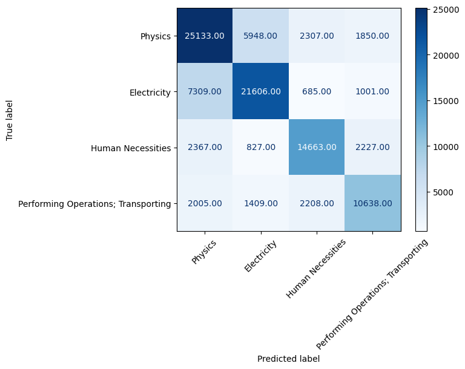

```python
# Manually defined labels
label_names = ["Physics", "Electricity", "Human Necessities", "Performing Operations; Transporting"]

# Plot confusion matrix with consistent lengths
plot_confusion_matrix(y_pred, y_test_truncated, label_names)
```

```python
# plot_confusion_matrix(y_pred, y_test, chunked_train_dataset.features["labels"].names)
```

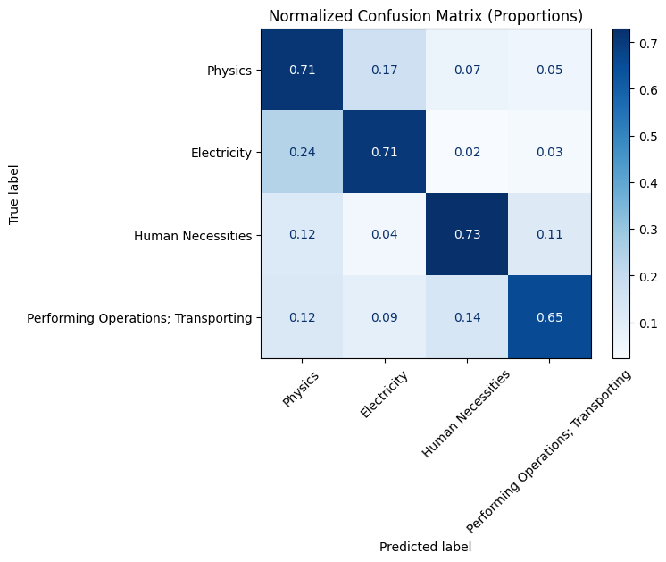

```python
from sklearn.metrics import ConfusionMatrixDisplay, confusion_matrix
import matplotlib.pyplot as plt
import numpy as np

def plot_confusion_matrix(y_pred, y_true, labels):
    # Compute confusion matrix and normalize it
    cm = confusion_matrix(y_true, y_pred)
    # axis=1 specifies that the summation should happen along each row (i.e., across columns).
    cm_normalized = cm.astype('float') / cm.sum(axis=1)[:, np.newaxis]

    # Display the normalized confusion matrix with values between 0 and 1
    disp = ConfusionMatrixDisplay(confusion_matrix=cm_normalized, display_labels=labels)
    disp.plot(cmap="Blues", values_format=".2f")  # Display with two decimal places
    plt.xticks(rotation=45)  # Rotate x-axis labels if needed
    plt.title("Normalized Confusion Matrix (Proportions)")
    plt.show()

# Use the defined label names
label_names = ["Physics", "Electricity", "Human Necessities", "Performing Operations; Transporting"]
plot_confusion_matrix(y_pred, y_test_truncated, label_names)
```

### Accuracy from Method 2: Fine-tune a transformer model by segmenting the text is slightly worse than Method 1's 0.72.

### Using overlapping chunks in Method 2 will likely improve accuracy by preserving more context across segments and enhancing prediction consistency. However, I should be mindful of the computational trade-offs.

### The segmentation approach used in Method 2 is a fixed-length segmentation with non-overlapping chunks. Here’s how it works:

Fixed Length: Each segment (chunk) is created by splitting the document into consecutive sequences of words, each up to a specified maximum length (max_length).

Non-Overlapping Chunks: The chunk_text function iterates over the text in steps of max_length words without any overlap. Each chunk is independent and does not share content with adjacent chunks.

Consistent Labeling: Each chunk inherits the original document’s label, ensuring all segments reflect the document’s classification.

This approach allows for efficient processing of long documents by breaking them down into manageable, non-overlapping segments, each fitting within the model's input constraints. This segmentation method is particularly useful when overlap is not needed to maintain context between segments.

### Production-Ready Post-Processing for Document Classification with Segmentation

To deploy the segmentation model (Method 2) effectively, a structured approach for aggregating segment predictions is needed to classify entire documents accurately. Here’s an outline:

#### Post-Processing Workflow:

1. **Segment and Predict**:
   - **Segment**: For each incoming document, segment it using the same tokenizer, `max_length` and other settings as during training.
   - **Predict**: Pass each segment through the model to generate prediction scores for each class.
2. **Aggregate Predictions**:
   - **Majority Voting**: Assign the document to the most frequently predicted class across segments. This is simple and effective for clear-cut classes.
   - **Probability Averaging**: Average the model’s softmax probabilities across segments and select the class with the highest mean probability. This approach leverages model confidence in each segment’s prediction.
3. **Optional Thresholding**:
   - **Confidence Threshold**: Set a threshold for prediction confidence; if the highest averaged probability is too low, flag the document for human review.
4. **Edge Case Handling**:
   - **Single-Segment Documents**: For short documents that fit in one segment, use the segment’s prediction as the document’s prediction.
   - **Varied Segment Predictions**: If segment predictions vary widely, flag for review, as this may indicate multiple topics or crucial content split by segmentation.

#### Production Considerations:

- **Optimize for Performance**: Segmenting large documents can be computationally expensive, so ensure efficiency in processing.
- **Monitor and Log**: Track model performance in production and log cases that require manual review.
- **Feedback Loop**: Feed manually reviewed cases back into training to continuously refine and improve the model.

By implementing these steps, we ensure that the segmentation model not only performs well in tests but also functions reliably and accurately in real-world applications.